# Lending Club Case Study

### **Import all the necessary libraries**

```python
import numpy as np
import pandas as pd
import matplotlib.pyplot as plt
from matplotlib import style
import seaborn as sns
from scipy import stats
from datetime import datetime
import warnings
warnings.filterwarnings('ignore')
```

```python
loan = pd.read_csv('loan.csv', low_memory=False)
```

```python
loan.shape
```

```
(39717, 111)
```

```python
loan.describe()
```

|  | id | member_id | loan_amnt | funded_amnt | funded_amnt_inv | installment | annual_inc | dti | delinq_2yrs | inq_last_6mths | ... | num_tl_90g_dpd_24m | num_tl_op_past_12m | pct_tl_nvr_dlq | percent_bc_gt_75 | pub_rec_bankruptcies | tax_liens | tot_hi_cred_lim | total_bal_ex_mort | total_bc_limit | total_il_high_credit_limit |
| --- | --- | --- | --- | --- | --- | --- | --- | --- | --- | --- | --- | --- | --- | --- | --- | --- | --- | --- | --- | --- | --- |
| count | 3.971700e+04 | 3.971700e+04 | 39717.000000 | 39717.000000 | 39717.000000 | 39717.000000 | 3.971700e+04 | 39717.000000 | 39717.000000 | 39717.000000 | ... | 0.0 | 0.0 | 0.0 | 0.0 | 39020.000000 | 39678.0 | 0.0 | 0.0 | 0.0 | 0.0 |
| mean | 6.831319e+05 | 8.504636e+05 | 11219.443815 | 10947.713196 | 10397.448868 | 324.561922 | 6.896893e+04 | 13.315130 | 0.146512 | 0.869200 | ... | NaN | NaN | NaN | NaN | 0.043260 | 0.0 | NaN | NaN | NaN | NaN |
| std | 2.106941e+05 | 2.656783e+05 | 7456.670694 | 7187.238670 | 7128.450439 | 208.874874 | 6.379377e+04 | 6.678594 | 0.491812 | 1.070219 | ... | NaN | NaN | NaN | NaN | 0.204324 | 0.0 | NaN | NaN | NaN | NaN |
| min | 5.473400e+04 | 7.069900e+04 | 500.000000 | 500.000000 | 0.000000 | 15.690000 | 4.000000e+03 | 0.000000 | 0.000000 | 0.000000 | ... | NaN | NaN | NaN | NaN | 0.000000 | 0.0 | NaN | NaN | NaN | NaN |
| 25% | 5.162210e+05 | 6.667800e+05 | 5500.000000 | 5400.000000 | 5000.000000 | 167.020000 | 4.040400e+04 | 8.170000 | 0.000000 | 0.000000 | ... | NaN | NaN | NaN | NaN | 0.000000 | 0.0 | NaN | NaN | NaN | NaN |
| 50% | 6.656650e+05 | 8.508120e+05 | 10000.000000 | 9600.000000 | 8975.000000 | 280.220000 | 5.900000e+04 | 13.400000 | 0.000000 | 1.000000 | ... | NaN | NaN | NaN | NaN | 0.000000 | 0.0 | NaN | NaN | NaN | NaN |
| 75% | 8.377550e+05 | 1.047339e+06 | 15000.000000 | 15000.000000 | 14400.000000 | 430.780000 | 8.230000e+04 | 18.600000 | 0.000000 | 1.000000 | ... | NaN | NaN | NaN | NaN | 0.000000 | 0.0 | NaN | NaN | NaN | NaN |
| max | 1.077501e+06 | 1.314167e+06 | 35000.000000 | 35000.000000 | 35000.000000 | 1305.190000 | 6.000000e+06 | 29.990000 | 11.000000 | 8.000000 | ... | NaN | NaN | NaN | NaN | 2.000000 | 0.0 | NaN | NaN | NaN | NaN |

8 rows × 87 columns

# Data Cleaning

```python
loan.isnull().sum()
```

```
id                                0
member_id                         0
loan_amnt                         0
funded_amnt                       0
funded_amnt_inv                   0
                              ...
tax_liens                        39
tot_hi_cred_lim               39717
total_bal_ex_mort             39717
total_bc_limit                39717
total_il_high_credit_limit    39717
Length: 111, dtype: int64
```

#### check for missing values

```python
missing = round(100*(loan.isnull().sum()/len(loan.id)), 2)
missing.loc[missing > 0]
```

```
emp_title                       6.19
emp_length                      2.71
desc                           32.58
title                           0.03
mths_since_last_delinq         64.66
                               ...
tax_liens                       0.10
tot_hi_cred_lim               100.00
total_bal_ex_mort             100.00
total_bc_limit                100.00
total_il_high_credit_limit    100.00
Length: 68, dtype: float64
```

```python
columns_with_missing_values = list(missing[missing >= 50].index)

len(columns_with_missing_values)
```

```
57
```

### **Drop all the 50% missing values columns, because it won't help for analysis.**

```python
#drop column with more than 50% missing values
loan = loan.drop(columns_with_missing_values,axis=1)
loan.shape
```

```
(39717, 54)
```

```python
#check for missing values again
missing = round(100*(loan.isnull().sum()/len(loan.id)), 2)
missing[missing != 0]
```

```
emp_title                      6.19
emp_length                     2.71
desc                          32.58
title                          0.03
revol_util                     0.13
last_pymnt_d                   0.18
last_credit_pull_d             0.01
collections_12_mths_ex_med     0.14
chargeoff_within_12_mths       0.14
pub_rec_bankruptcies           1.75
tax_liens                      0.10
dtype: float64
```

### Finding any arbitrary columns and can’t be used.

```python
print("unique emp_title : %d"  % len(loan.emp_title.unique()))
print("unique emp_length : %d"  % len(loan.emp_length.unique()))
print("unique desc : %d"  % len(loan.desc.unique()))
print("unique title : %d"  % len(loan.title.unique()))
print("unique revol_util : %d"  % len(loan.revol_util.unique()))
print("unique title : %d"  % len(loan.title.unique()))
print("unique last_pymnt_d : %d"  % len(loan.last_pymnt_d.unique()))
print("unique last_credit_pull_d : %d"  % len(loan.last_credit_pull_d.unique()))
print("unique collections_12_mths_ex_med : %d"  % len(loan.collections_12_mths_ex_med.unique()))
print("unique chargeoff_within_12_mths : %d"  % len(loan.chargeoff_within_12_mths.unique()))
print("unique pub_rec_bankruptcies : %d"  % len(loan.pub_rec_bankruptcies.unique()))
print("unique tax_liens : %d"  % len(loan.tax_liens.unique()))
```

```
unique emp_title : 28821
unique emp_length : 12
unique desc : 26528
unique title : 19616
unique revol_util : 1090
unique title : 19616
unique last_pymnt_d : 102
unique last_credit_pull_d : 107
unique collections_12_mths_ex_med : 2
unique chargeoff_within_12_mths : 2
unique pub_rec_bankruptcies : 4
unique tax_liens : 2
```

```python
loan.emp_length.unique()
```

```
array(['10+ years', '< 1 year', '1 year', '3 years', '8 years', '9 years',
       '4 years', '5 years', '6 years', '2 years', '7 years', nan],
      dtype=object)
```

```python
loan.collections_12_mths_ex_med.unique()
```

```
array([ 0., nan])
```

```python
loan.chargeoff_within_12_mths.unique()
```

```
array([ 0., nan])
```

```python
loan.tax_liens.unique()
```

```
array([ 0., nan])
```

```python
loan.pub_rec_bankruptcies.unique()
```

```
array([ 0.,  1.,  2., nan])
```

```python
#collections_12_mths_ex_med, chargeoff_within_12_mths and tax_liens have only 0 and nan. So better to exclude this in analysis.
drop_columnlist = ['collections_12_mths_ex_med', 'chargeoff_within_12_mths', 'tax_liens', ]
loan = loan.drop(drop_columnlist,axis=1)
```

```python
loan.shape
```

```
(39717, 51)
```

```python
missing = round(100*(loan.isnull().sum()/len(loan.id)), 2)
missing[missing != 0]
```

```
emp_title                6.19
emp_length               2.71
desc                    32.58
title                    0.03
revol_util               0.13
last_pymnt_d             0.18
last_credit_pull_d       0.01
pub_rec_bankruptcies     1.75
dtype: float64
```

```python
#lets remove desc as it has 32% data missing.
loan = loan.drop('desc',axis=1)
```

```python
loan.shape
```

```
(39717, 50)
```

```python
#lets relook at pub_rec_bankruptcies as it has 1.75% data missing
loan.pub_rec_bankruptcies.unique()
```

```
array([ 0.,  1.,  2., nan])
```

```python
loan.pub_rec_bankruptcies.value_counts()
```

```
0.0    37339
1.0     1674
2.0        7
Name: pub_rec_bankruptcies, dtype: int64
```

```python
loan.emp_title.unique()
```

```
array([nan, 'Ryder', 'AIR RESOURCES BOARD', ..., 'FiSite Research',
       'Squarewave Solutions, Ltd.', 'Evergreen Center'], dtype=object)
```

```python
loan.emp_title.value_counts()
```

```
US Army                  134
Bank of America          109
IBM                       66
AT&T                      59
Kaiser Permanente         56
                        ...
TowerBank                  1
BMW of Bellevue            1
NORWEGIAN CRUISE LINE      1
K2 Group, Inc              1
Schneider Finance          1
Name: emp_title, Length: 28820, dtype: int64
```

```python
loan.emp_title.isnull().value_counts()
```

```
False    37258
True      2459
Name: emp_title, dtype: int64
```

```python
loan.emp_length.value_counts()
```

```
10+ years    8879
< 1 year     4583
2 years      4388
3 years      4095
4 years      3436
5 years      3282
1 year       3240
6 years      2229
7 years      1773
8 years      1479
9 years      1258
Name: emp_length, dtype: int64
```

```python
loan.emp_length.isnull().value_counts()
```

```
False    38642
True      1075
Name: emp_length, dtype: int64
```

```python
#2459 are missing emp title and 1075 are missing emp length
loan=loan[~loan.emp_title.isnull()]
loan=loan[~loan.emp_length.isnull()]
```

```python
loan.shape
```

```
(37202, 50)
```

```python
#recheck for missing values
missing = round(100*(loan.isnull().sum()/len(loan.id)), 2)
missing[missing != 0]
```

```
title                   0.02
revol_util              0.12
last_pymnt_d            0.17
pub_rec_bankruptcies    1.76
dtype: float64
```

```python
#lets remove the rows with pub_rec_bankruptcies as missing
loan=loan[~loan.pub_rec_bankruptcies.isnull()]
```

```python
#recheck for missing values
missing = round(100*(loan.isnull().sum()/len(loan.id)), 2)
missing[missing != 0]
```

```
title           0.02
revol_util      0.13
last_pymnt_d    0.18
dtype: float64
```

```python
#lets cleanup all rows with missing values
loan=loan[~loan.title.isnull()]
loan=loan[~loan.revol_util.isnull()]
loan=loan[~loan.last_pymnt_d.isnull()]
```

```python
loan.shape
```

```
(36433, 50)
```

```python
loan.describe()
```

|  | id | member_id | loan_amnt | funded_amnt | funded_amnt_inv | installment | annual_inc | dti | delinq_2yrs | inq_last_6mths | ... | total_rec_prncp | total_rec_int | total_rec_late_fee | recoveries | collection_recovery_fee | last_pymnt_amnt | policy_code | acc_now_delinq | delinq_amnt | pub_rec_bankruptcies |
| --- | --- | --- | --- | --- | --- | --- | --- | --- | --- | --- | --- | --- | --- | --- | --- | --- | --- | --- | --- | --- | --- |
| count | 3.643300e+04 | 3.643300e+04 | 36433.000000 | 36433.000000 | 36433.000000 | 36433.000000 | 3.643300e+04 | 36433.000000 | 36433.000000 | 36433.00000 | ... | 36433.000000 | 36433.000000 | 36433.000000 | 36433.000000 | 36433.000000 | 36433.000000 | 36433.0 | 36433.0 | 36433.0 | 36433.000000 |
| mean | 6.909826e+05 | 8.610707e+05 | 11307.679851 | 11032.834244 | 10601.325781 | 326.186394 | 6.930522e+04 | 13.444131 | 0.146131 | 0.86493 | ... | 9912.408471 | 2304.404937 | 1.299840 | 92.855490 | 11.677065 | 2742.955476 | 1.0 | 0.0 | 0.0 | 0.041418 |
| std | 2.026435e+05 | 2.538822e+05 | 7433.859357 | 7166.484281 | 7072.842604 | 207.389943 | 6.354244e+04 | 6.643308 | 0.492199 | 1.06343 | ... | 7053.212865 | 2629.542911 | 7.065629 | 682.047187 | 140.880327 | 4473.528922 | 0.0 | 0.0 | 0.0 | 0.200221 |
| min | 5.574200e+04 | 1.124930e+05 | 500.000000 | 500.000000 | 0.000000 | 16.080000 | 4.000000e+03 | 0.000000 | 0.000000 | 0.00000 | ... | 0.000000 | 6.220000 | 0.000000 | 0.000000 | 0.000000 | 0.010000 | 1.0 | 0.0 | 0.0 | 0.000000 |
| 25% | 5.226860e+05 | 6.755300e+05 | 5600.000000 | 5500.000000 | 5000.000000 | 168.900000 | 4.200000e+04 | 8.360000 | 0.000000 | 0.00000 | ... | 4800.000000 | 678.010000 | 0.000000 | 0.000000 | 0.000000 | 226.280000 | 1.0 | 0.0 | 0.0 | 0.000000 |
| 50% | 6.705630e+05 | 8.569510e+05 | 10000.000000 | 10000.000000 | 9202.846434 | 283.280000 | 6.000000e+04 | 13.540000 | 0.000000 | 1.00000 | ... | 8123.600000 | 1379.820000 | 0.000000 | 0.000000 | 0.000000 | 571.700000 | 1.0 | 0.0 | 0.0 | 0.000000 |
| 75% | 8.399030e+05 | 1.049791e+06 | 15000.000000 | 15000.000000 | 14508.454150 | 432.220000 | 8.300000e+04 | 18.690000 | 0.000000 | 1.00000 | ... | 14000.000000 | 2891.860000 | 0.000000 | 0.000000 | 0.000000 | 3457.580000 | 1.0 | 0.0 | 0.0 | 0.000000 |
| max | 1.077430e+06 | 1.314167e+06 | 35000.000000 | 35000.000000 | 35000.000000 | 1305.190000 | 6.000000e+06 | 29.990000 | 11.000000 | 8.00000 | ... | 35000.020000 | 23563.680000 | 180.200000 | 29623.350000 | 7002.190000 | 36115.200000 | 1.0 | 0.0 | 0.0 | 2.000000 |

8 rows × 28 columns

```python
#recheck missing values now
missing =round(100*(loan.isnull().sum()/len(loan.id)), 2)
missing[missing != 0]
```

```
Series([], dtype: float64)
```

```python
#no missing values
```

```python
#keep a backup of cleaned up data
loan.to_csv('loan_clean.csv', encoding='utf-8', index=False)
```

```python
clean_loan = loan[:]
```

```python
loan.shape
```

```
(36433, 50)
```

```python
clean_loan.shape
```

```
(36433, 50)
```

```python
loan.nunique().sort_values()
```

```
acc_now_delinq                 1
application_type               1
policy_code                    1
initial_list_status            1
delinq_amnt                    1
pymnt_plan                     1
term                           2
pub_rec_bankruptcies           3
loan_status                    3
verification_status            3
home_ownership                 4
pub_rec                        5
grade                          7
inq_last_6mths                 9
delinq_2yrs                   11
emp_length                    11
purpose                       14
sub_grade                     35
open_acc                      38
addr_state                    49
issue_d                       52
total_acc                     79
last_credit_pull_d            96
last_pymnt_d                  97
int_rate                     334
earliest_cr_line             510
zip_code                     806
loan_amnt                    863
funded_amnt                 1024
out_prncp                   1064
out_prncp_inv               1065
revol_util                  1082
total_rec_late_fee          1194
collection_recovery_fee     2386
dti                         2857
recoveries                  3585
annual_inc                  4924
total_rec_prncp             7254
funded_amnt_inv             7474
installment                14367
title                      17954
revol_bal                  20790
emp_title                  28207
last_pymnt_amnt            32467
total_rec_int              32523
total_pymnt_inv            34524
total_pymnt                34802
url                        36433
member_id                  36433
id                         36433
dtype: int64
```

```python
loan.acc_now_delinq
```

```
1        0
3        0
4        0
5        0
6        0
        ..
39551    0
39562    0
39623    0
39666    0
39680    0
Name: acc_now_delinq, Length: 36433, dtype: int64
```

```python
loan.application_type
```

```
1        INDIVIDUAL
3        INDIVIDUAL
4        INDIVIDUAL
5        INDIVIDUAL
6        INDIVIDUAL
            ...
39551    INDIVIDUAL
39562    INDIVIDUAL
39623    INDIVIDUAL
39666    INDIVIDUAL
39680    INDIVIDUAL
Name: application_type, Length: 36433, dtype: object
```

```python
loan.policy_code
```

```
1        1
3        1
4        1
5        1
6        1
        ..
39551    1
39562    1
39623    1
39666    1
39680    1
Name: policy_code, Length: 36433, dtype: int64
```

```python
loan.initial_list_status
```

```
1        f
3        f
4        f
5        f
6        f
        ..
39551    f
39562    f
39623    f
39666    f
39680    f
Name: initial_list_status, Length: 36433, dtype: object
```

```python
loan.delinq_amnt
```

```
1        0
3        0
4        0
5        0
6        0
        ..
39551    0
39562    0
39623    0
39666    0
39680    0
Name: delinq_amnt, Length: 36433, dtype: int64
```

```python
loan.pymnt_plan
```

```
1        n
3        n
4        n
5        n
6        n
        ..
39551    n
39562    n
39623    n
39666    n
39680    n
Name: pymnt_plan, Length: 36433, dtype: object
```

```python
#drop all the above columns we checked as it has same vlaue for all rows and wont help analysis.
columns_tobe_dropped = ['pymnt_plan', 'delinq_amnt', 'initial_list_status', 'policy_code', 'application_type', 'acc_now_delinq']
loan= loan.drop(columns_tobe_dropped,axis=1)
```

```python
loan.shape
```

```
(36433, 44)
```

```python
loan.id
```

```
1        1077430
3        1076863
4        1075358
5        1075269
6        1069639
          ...
39551     158706
39562     154154
39623     132892
39666     119043
39680     112496
Name: id, Length: 36433, dtype: int64
```

```python
loan.member_id
```

```
1        1314167
3        1277178
4        1311748
5        1311441
6        1304742
          ...
39551     158450
39562     151536
39623     132889
39666     119040
39680     112493
Name: member_id, Length: 36433, dtype: int64
```

### Delete *id, member_id, url, zip_code* columns— they are arbitrary and can’t be used.

```python
#drop id and member id as its a unique num for each customer, nothing to do with default.
columns_tobe_dropped = ['id', 'member_id']
loan= loan.drop(columns_tobe_dropped,axis=1)
```

```python
loan.shape
```

```
(36433, 42)
```

```python
loan.nunique().sort_values()
```

```
term                           2
pub_rec_bankruptcies           3
loan_status                    3
verification_status            3
home_ownership                 4
pub_rec                        5
grade                          7
inq_last_6mths                 9
emp_length                    11
delinq_2yrs                   11
purpose                       14
sub_grade                     35
open_acc                      38
addr_state                    49
issue_d                       52
total_acc                     79
last_credit_pull_d            96
last_pymnt_d                  97
int_rate                     334
earliest_cr_line             510
zip_code                     806
loan_amnt                    863
funded_amnt                 1024
out_prncp                   1064
out_prncp_inv               1065
revol_util                  1082
total_rec_late_fee          1194
collection_recovery_fee     2386
dti                         2857
recoveries                  3585
annual_inc                  4924
total_rec_prncp             7254
funded_amnt_inv             7474
installment                14367
title                      17954
revol_bal                  20790
emp_title                  28207
last_pymnt_amnt            32467
total_rec_int              32523
total_pymnt_inv            34524
total_pymnt                34802
url                        36433
dtype: int64
```

```python
loan.url
```

```
1        https://lendingclub.com/browse/loanDetail.acti...
3        https://lendingclub.com/browse/loanDetail.acti...
4        https://lendingclub.com/browse/loanDetail.acti...
5        https://lendingclub.com/browse/loanDetail.acti...
6        https://lendingclub.com/browse/loanDetail.acti...
                               ...
39551    https://lendingclub.com/browse/loanDetail.acti...
39562    https://lendingclub.com/browse/loanDetail.acti...
39623    https://lendingclub.com/browse/loanDetail.acti...
39666    https://lendingclub.com/browse/loanDetail.acti...
39680    https://lendingclub.com/browse/loanDetail.acti...
Name: url, Length: 36433, dtype: object
```

```python
loan.zip_code
```

```
1        309xx
3        917xx
4        972xx
5        852xx
6        280xx
         ...
39551    201xx
39562    226xx
39623    207xx
39666    201xx
39680    479xx
Name: zip_code, Length: 36433, dtype: object
```

```python
#lets remove url and zip code as well
columns_tobe_dropped = ['url', 'zip_code']
loan= loan.drop(columns_tobe_dropped,axis=1)
```

```python
loan.shape
```

```
(36433, 40)
```

```python
#lets see if we can cleanup something more
loan.nunique().sort_values()
```

```
term                           2
pub_rec_bankruptcies           3
loan_status                    3
verification_status            3
home_ownership                 4
pub_rec                        5
grade                          7
inq_last_6mths                 9
emp_length                    11
delinq_2yrs                   11
purpose                       14
sub_grade                     35
open_acc                      38
addr_state                    49
issue_d                       52
total_acc                     79
last_credit_pull_d            96
last_pymnt_d                  97
int_rate                     334
earliest_cr_line             510
loan_amnt                    863
funded_amnt                 1024
out_prncp                   1064
out_prncp_inv               1065
revol_util                  1082
total_rec_late_fee          1194
collection_recovery_fee     2386
dti                         2857
recoveries                  3585
annual_inc                  4924
total_rec_prncp             7254
funded_amnt_inv             7474
installment                14367
title                      17954
revol_bal                  20790
emp_title                  28207
last_pymnt_amnt            32467
total_rec_int              32523
total_pymnt_inv            34524
total_pymnt                34802
dtype: int64
```

```python
loan.earliest_cr_line
```

```
1        Apr-99
3        Feb-96
4        Jan-96
5        Nov-04
6        Jul-05
          ...
39551    Dec-00
39562    Mar-00
39623    Aug-97
39666    Nov-92
39680    Jul-00
Name: earliest_cr_line, Length: 36433, dtype: object
```

```python
loan.dti
```

```
1         1.00
3        20.00
4        17.94
5        11.20
6        23.51
         ...
39551     9.23
39562     7.51
39623     5.08
39666    13.50
39680     7.47
Name: dti, Length: 36433, dtype: float64
```

```python
loan.funded_amnt
```

```
1         2500
3        10000
4         3000
5         5000
6         7000
         ...
39551    12375
39562     4800
39623     9000
39666    15450
39680     3000
Name: funded_amnt, Length: 36433, dtype: int64
```

```python
loan.head()
```

|  | loan_amnt | funded_amnt | funded_amnt_inv | term | int_rate | installment | grade | sub_grade | emp_title | emp_length | ... | total_pymnt_inv | total_rec_prncp | total_rec_int | total_rec_late_fee | recoveries | collection_recovery_fee | last_pymnt_d | last_pymnt_amnt | last_credit_pull_d | pub_rec_bankruptcies |
| --- | --- | --- | --- | --- | --- | --- | --- | --- | --- | --- | --- | --- | --- | --- | --- | --- | --- | --- | --- | --- | --- |
| 1 | 2500 | 2500 | 2500.0 | 60 months | 15.27% | 59.83 | C | C4 | Ryder | < 1 year | ... | 1008.71 | 456.46 | 435.17 | 0.00 | 117.08 | 1.11 | Apr-13 | 119.66 | Sep-13 | 0.0 |
| 3 | 10000 | 10000 | 10000.0 | 36 months | 13.49% | 339.31 | C | C1 | AIR RESOURCES BOARD | 10+ years | ... | 12231.89 | 10000.00 | 2214.92 | 16.97 | 0.00 | 0.00 | Jan-15 | 357.48 | Apr-16 | 0.0 |
| 4 | 3000 | 3000 | 3000.0 | 60 months | 12.69% | 67.79 | B | B5 | University Medical Group | 1 year | ... | 3513.33 | 2475.94 | 1037.39 | 0.00 | 0.00 | 0.00 | May-16 | 67.79 | May-16 | 0.0 |
| 5 | 5000 | 5000 | 5000.0 | 36 months | 7.90% | 156.46 | A | A4 | Veolia Transportaton | 3 years | ... | 5632.21 | 5000.00 | 632.21 | 0.00 | 0.00 | 0.00 | Jan-15 | 161.03 | Jan-16 | 0.0 |
| 6 | 7000 | 7000 | 7000.0 | 60 months | 15.96% | 170.08 | C | C5 | Southern Star Photography | 8 years | ... | 10110.84 | 6985.61 | 3125.23 | 0.00 | 0.00 | 0.00 | May-16 | 1313.76 | May-16 | 0.0 |

5 rows × 40 columns

```python
loan.emp_length.value_counts()
```

```
10+ years    8407
2 years      4178
< 1 year     4052
3 years      3914
4 years      3297
5 years      3129
1 year       3026
6 years      2121
7 years      1697
8 years      1405
9 years      1207
Name: emp_length, dtype: int64
```

### Modify *10+* with *10* and *'< 1'* with *0* and removing by *'years'*

```python
#modify 10+ with 10 and < 1 with 0 and remove year
emp_length_dict = {
    '< 1 year' : 0,
    '1 year' : 1,
    '2 years' : 2,
    '3 years' : 3,
    '4 years' : 4,
    '5 years' : 5,
    '6 years' : 6,
    '7 years' : 7,
    '8 years' : 8,
    '9 years' : 9,
    '10+ years' : 10
}
loan = loan.replace({"emp_length": emp_length_dict })
```

```python
loan.emp_length.value_counts()
```

```
10    8407
2     4178
0     4052
3     3914
4     3297
5     3129
1     3026
6     2121
7     1697
8     1405
9     1207
Name: emp_length, dtype: int64
```

### Modify the *term* column by removing *'months'* and convert that into *int* datatype

```python
loan.term.value_counts()
```

```
 36 months    26377
 60 months    10056
Name: term, dtype: int64
```

```python
#remove months from here
loan['term'] = loan.term.apply(lambda x: x.split()[0])
```

```python
loan.term.value_counts()
```

```
36    26377
60    10056
Name: term, dtype: int64
```

```python
loan.head()
```

|  | loan_amnt | funded_amnt | funded_amnt_inv | term | int_rate | installment | grade | sub_grade | emp_title | emp_length | ... | total_pymnt_inv | total_rec_prncp | total_rec_int | total_rec_late_fee | recoveries | collection_recovery_fee | last_pymnt_d | last_pymnt_amnt | last_credit_pull_d | pub_rec_bankruptcies |
| --- | --- | --- | --- | --- | --- | --- | --- | --- | --- | --- | --- | --- | --- | --- | --- | --- | --- | --- | --- | --- | --- |
| 1 | 2500 | 2500 | 2500.0 | 60 | 15.27% | 59.83 | C | C4 | Ryder | 0 | ... | 1008.71 | 456.46 | 435.17 | 0.00 | 117.08 | 1.11 | Apr-13 | 119.66 | Sep-13 | 0.0 |
| 3 | 10000 | 10000 | 10000.0 | 36 | 13.49% | 339.31 | C | C1 | AIR RESOURCES BOARD | 10 | ... | 12231.89 | 10000.00 | 2214.92 | 16.97 | 0.00 | 0.00 | Jan-15 | 357.48 | Apr-16 | 0.0 |
| 4 | 3000 | 3000 | 3000.0 | 60 | 12.69% | 67.79 | B | B5 | University Medical Group | 1 | ... | 3513.33 | 2475.94 | 1037.39 | 0.00 | 0.00 | 0.00 | May-16 | 67.79 | May-16 | 0.0 |
| 5 | 5000 | 5000 | 5000.0 | 36 | 7.90% | 156.46 | A | A4 | Veolia Transportaton | 3 | ... | 5632.21 | 5000.00 | 632.21 | 0.00 | 0.00 | 0.00 | Jan-15 | 161.03 | Jan-16 | 0.0 |
| 6 | 7000 | 7000 | 7000.0 | 60 | 15.96% | 170.08 | C | C5 | Southern Star Photography | 8 | ... | 10110.84 | 6985.61 | 3125.23 | 0.00 | 0.00 | 0.00 | May-16 | 1313.76 | May-16 | 0.0 |

5 rows × 40 columns

### Modify the *int_rate* column by removing *'%'* and converting into *float* datatype

```python
loan['int_rate'] = loan['int_rate'].str.strip('%').astype('float')
```

```python
loan.head()
```

|  | loan_amnt | funded_amnt | funded_amnt_inv | term | int_rate | installment | grade | sub_grade | emp_title | emp_length | ... | total_pymnt_inv | total_rec_prncp | total_rec_int | total_rec_late_fee | recoveries | collection_recovery_fee | last_pymnt_d | last_pymnt_amnt | last_credit_pull_d | pub_rec_bankruptcies |
| --- | --- | --- | --- | --- | --- | --- | --- | --- | --- | --- | --- | --- | --- | --- | --- | --- | --- | --- | --- | --- | --- |
| 1 | 2500 | 2500 | 2500.0 | 60 | 15.27 | 59.83 | C | C4 | Ryder | 0 | ... | 1008.71 | 456.46 | 435.17 | 0.00 | 117.08 | 1.11 | Apr-13 | 119.66 | Sep-13 | 0.0 |
| 3 | 10000 | 10000 | 10000.0 | 36 | 13.49 | 339.31 | C | C1 | AIR RESOURCES BOARD | 10 | ... | 12231.89 | 10000.00 | 2214.92 | 16.97 | 0.00 | 0.00 | Jan-15 | 357.48 | Apr-16 | 0.0 |
| 4 | 3000 | 3000 | 3000.0 | 60 | 12.69 | 67.79 | B | B5 | University Medical Group | 1 | ... | 3513.33 | 2475.94 | 1037.39 | 0.00 | 0.00 | 0.00 | May-16 | 67.79 | May-16 | 0.0 |
| 5 | 5000 | 5000 | 5000.0 | 36 | 7.90 | 156.46 | A | A4 | Veolia Transportaton | 3 | ... | 5632.21 | 5000.00 | 632.21 | 0.00 | 0.00 | 0.00 | Jan-15 | 161.03 | Jan-16 | 0.0 |
| 6 | 7000 | 7000 | 7000.0 | 60 | 15.96 | 170.08 | C | C5 | Southern Star Photography | 8 | ... | 10110.84 | 6985.61 | 3125.23 | 0.00 | 0.00 | 0.00 | May-16 | 1313.76 | May-16 | 0.0 |

5 rows × 40 columns

```python
loan.revol_util
```

```
1         9.40%
3           21%
4        53.90%
5        28.30%
6        85.60%
          ...
39551    96.50%
39562    68.70%
39623    62.90%
39666    34.30%
39680    70.90%
Name: revol_util, Length: 36433, dtype: object
```

```python
loan.describe()
```

|  | loan_amnt | funded_amnt | funded_amnt_inv | int_rate | installment | emp_length | annual_inc | dti | delinq_2yrs | inq_last_6mths | ... | out_prncp_inv | total_pymnt | total_pymnt_inv | total_rec_prncp | total_rec_int | total_rec_late_fee | recoveries | collection_recovery_fee | last_pymnt_amnt | pub_rec_bankruptcies |
| --- | --- | --- | --- | --- | --- | --- | --- | --- | --- | --- | --- | --- | --- | --- | --- | --- | --- | --- | --- | --- | --- |
| count | 36433.000000 | 36433.000000 | 36433.000000 | 36433.000000 | 36433.000000 | 36433.000000 | 3.643300e+04 | 36433.000000 | 36433.000000 | 36433.00000 | ... | 36433.000000 | 36433.000000 | 36433.000000 | 36433.000000 | 36433.000000 | 36433.000000 | 36433.000000 | 36433.000000 | 36433.000000 | 36433.000000 |
| mean | 11307.679851 | 11032.834244 | 10601.325781 | 12.073862 | 326.186394 | 5.015645 | 6.930522e+04 | 13.444131 | 0.146131 | 0.86493 | ... | 52.213313 | 12310.968657 | 11841.070656 | 9912.408471 | 2304.404937 | 1.299840 | 92.855490 | 11.677065 | 2742.955476 | 0.041418 |
| std | 7433.859357 | 7166.484281 | 7072.842604 | 3.734758 | 207.389943 | 3.542914 | 6.354244e+04 | 6.643308 | 0.492199 | 1.06343 | ... | 378.443825 | 9048.420885 | 8911.319070 | 7053.212865 | 2629.542911 | 7.065629 | 682.047187 | 140.880327 | 4473.528922 | 0.200221 |
| min | 500.000000 | 500.000000 | 0.000000 | 5.420000 | 16.080000 | 0.000000 | 4.000000e+03 | 0.000000 | 0.000000 | 0.00000 | ... | 0.000000 | 33.730000 | 0.000000 | 0.000000 | 6.220000 | 0.000000 | 0.000000 | 0.000000 | 0.010000 | 0.000000 |
| 25% | 5600.000000 | 5500.000000 | 5000.000000 | 9.320000 | 168.900000 | 2.000000 | 4.200000e+04 | 8.360000 | 0.000000 | 0.00000 | ... | 0.000000 | 5672.557913 | 5413.410000 | 4800.000000 | 678.010000 | 0.000000 | 0.000000 | 0.000000 | 226.280000 | 0.000000 |
| 50% | 10000.000000 | 10000.000000 | 9202.846434 | 11.860000 | 283.280000 | 4.000000 | 6.000000e+04 | 13.540000 | 0.000000 | 1.00000 | ... | 0.000000 | 10101.589360 | 9632.040000 | 8123.600000 | 1379.820000 | 0.000000 | 0.000000 | 0.000000 | 571.700000 | 0.000000 |
| 75% | 15000.000000 | 15000.000000 | 14508.454150 | 14.650000 | 432.220000 | 9.000000 | 8.300000e+04 | 18.690000 | 0.000000 | 1.00000 | ... | 0.000000 | 16700.719980 | 16094.490000 | 14000.000000 | 2891.860000 | 0.000000 | 0.000000 | 0.000000 | 3457.580000 | 0.000000 |
| max | 35000.000000 | 35000.000000 | 35000.000000 | 24.400000 | 1305.190000 | 10.000000 | 6.000000e+06 | 29.990000 | 11.000000 | 8.00000 | ... | 6307.370000 | 58563.679930 | 58563.680000 | 35000.020000 | 23563.680000 | 180.200000 | 29623.350000 | 7002.190000 | 36115.200000 | 2.000000 |

8 rows × 25 columns

```python
loan['revol_util'] = loan['revol_util'].str.strip('%').astype('float')
```

```python
loan.describe()
```

|  | loan_amnt | funded_amnt | funded_amnt_inv | int_rate | installment | emp_length | annual_inc | dti | delinq_2yrs | inq_last_6mths | ... | out_prncp_inv | total_pymnt | total_pymnt_inv | total_rec_prncp | total_rec_int | total_rec_late_fee | recoveries | collection_recovery_fee | last_pymnt_amnt | pub_rec_bankruptcies |
| --- | --- | --- | --- | --- | --- | --- | --- | --- | --- | --- | --- | --- | --- | --- | --- | --- | --- | --- | --- | --- | --- |
| count | 36433.000000 | 36433.000000 | 36433.000000 | 36433.000000 | 36433.000000 | 36433.000000 | 3.643300e+04 | 36433.000000 | 36433.000000 | 36433.00000 | ... | 36433.000000 | 36433.000000 | 36433.000000 | 36433.000000 | 36433.000000 | 36433.000000 | 36433.000000 | 36433.000000 | 36433.000000 | 36433.000000 |
| mean | 11307.679851 | 11032.834244 | 10601.325781 | 12.073862 | 326.186394 | 5.015645 | 6.930522e+04 | 13.444131 | 0.146131 | 0.86493 | ... | 52.213313 | 12310.968657 | 11841.070656 | 9912.408471 | 2304.404937 | 1.299840 | 92.855490 | 11.677065 | 2742.955476 | 0.041418 |
| std | 7433.859357 | 7166.484281 | 7072.842604 | 3.734758 | 207.389943 | 3.542914 | 6.354244e+04 | 6.643308 | 0.492199 | 1.06343 | ... | 378.443825 | 9048.420885 | 8911.319070 | 7053.212865 | 2629.542911 | 7.065629 | 682.047187 | 140.880327 | 4473.528922 | 0.200221 |
| min | 500.000000 | 500.000000 | 0.000000 | 5.420000 | 16.080000 | 0.000000 | 4.000000e+03 | 0.000000 | 0.000000 | 0.00000 | ... | 0.000000 | 33.730000 | 0.000000 | 0.000000 | 6.220000 | 0.000000 | 0.000000 | 0.000000 | 0.010000 | 0.000000 |
| 25% | 5600.000000 | 5500.000000 | 5000.000000 | 9.320000 | 168.900000 | 2.000000 | 4.200000e+04 | 8.360000 | 0.000000 | 0.00000 | ... | 0.000000 | 5672.557913 | 5413.410000 | 4800.000000 | 678.010000 | 0.000000 | 0.000000 | 0.000000 | 226.280000 | 0.000000 |
| 50% | 10000.000000 | 10000.000000 | 9202.846434 | 11.860000 | 283.280000 | 4.000000 | 6.000000e+04 | 13.540000 | 0.000000 | 1.00000 | ... | 0.000000 | 10101.589360 | 9632.040000 | 8123.600000 | 1379.820000 | 0.000000 | 0.000000 | 0.000000 | 571.700000 | 0.000000 |
| 75% | 15000.000000 | 15000.000000 | 14508.454150 | 14.650000 | 432.220000 | 9.000000 | 8.300000e+04 | 18.690000 | 0.000000 | 1.00000 | ... | 0.000000 | 16700.719980 | 16094.490000 | 14000.000000 | 2891.860000 | 0.000000 | 0.000000 | 0.000000 | 3457.580000 | 0.000000 |
| max | 35000.000000 | 35000.000000 | 35000.000000 | 24.400000 | 1305.190000 | 10.000000 | 6.000000e+06 | 29.990000 | 11.000000 | 8.00000 | ... | 6307.370000 | 58563.679930 | 58563.680000 | 35000.020000 | 23563.680000 | 180.200000 | 29623.350000 | 7002.190000 | 36115.200000 | 2.000000 |

8 rows × 26 columns

```python
loan.nunique().sort_values()
```

```
term                           2
pub_rec_bankruptcies           3
loan_status                    3
verification_status            3
home_ownership                 4
pub_rec                        5
grade                          7
inq_last_6mths                 9
emp_length                    11
delinq_2yrs                   11
purpose                       14
sub_grade                     35
open_acc                      38
addr_state                    49
issue_d                       52
total_acc                     79
last_credit_pull_d            96
last_pymnt_d                  97
int_rate                     334
earliest_cr_line             510
loan_amnt                    863
funded_amnt                 1024
out_prncp                   1064
out_prncp_inv               1065
revol_util                  1082
total_rec_late_fee          1194
collection_recovery_fee     2386
dti                         2857
recoveries                  3585
annual_inc                  4924
total_rec_prncp             7254
funded_amnt_inv             7474
installment                14367
title                      17954
revol_bal                  20790
emp_title                  28207
last_pymnt_amnt            32467
total_rec_int              32523
total_pymnt_inv            34524
total_pymnt                34802
dtype: int64
```

```python
loan
```

|  | loan_amnt | funded_amnt | funded_amnt_inv | term | int_rate | installment | grade | sub_grade | emp_title | emp_length | ... | total_pymnt_inv | total_rec_prncp | total_rec_int | total_rec_late_fee | recoveries | collection_recovery_fee | last_pymnt_d | last_pymnt_amnt | last_credit_pull_d | pub_rec_bankruptcies |
| --- | --- | --- | --- | --- | --- | --- | --- | --- | --- | --- | --- | --- | --- | --- | --- | --- | --- | --- | --- | --- | --- |
| 1 | 2500 | 2500 | 2500.0 | 60 | 15.27 | 59.83 | C | C4 | Ryder | 0 | ... | 1008.71 | 456.46 | 435.17 | 0.00 | 117.08 | 1.11 | Apr-13 | 119.66 | Sep-13 | 0.0 |
| 3 | 10000 | 10000 | 10000.0 | 36 | 13.49 | 339.31 | C | C1 | AIR RESOURCES BOARD | 10 | ... | 12231.89 | 10000.00 | 2214.92 | 16.97 | 0.00 | 0.00 | Jan-15 | 357.48 | Apr-16 | 0.0 |
| 4 | 3000 | 3000 | 3000.0 | 60 | 12.69 | 67.79 | B | B5 | University Medical Group | 1 | ... | 3513.33 | 2475.94 | 1037.39 | 0.00 | 0.00 | 0.00 | May-16 | 67.79 | May-16 | 0.0 |
| 5 | 5000 | 5000 | 5000.0 | 36 | 7.90 | 156.46 | A | A4 | Veolia Transportaton | 3 | ... | 5632.21 | 5000.00 | 632.21 | 0.00 | 0.00 | 0.00 | Jan-15 | 161.03 | Jan-16 | 0.0 |
| 6 | 7000 | 7000 | 7000.0 | 60 | 15.96 | 170.08 | C | C5 | Southern Star Photography | 8 | ... | 10110.84 | 6985.61 | 3125.23 | 0.00 | 0.00 | 0.00 | May-16 | 1313.76 | May-16 | 0.0 |
| ... | ... | ... | ... | ... | ... | ... | ... | ... | ... | ... | ... | ... | ... | ... | ... | ... | ... | ... | ... | ... | ... |
| 39551 | 12375 | 12375 | 1000.0 | 36 | 10.91 | 404.62 | C | C3 | Fullmoon Software | 2 | ... | 1161.29 | 12375.00 | 1995.92 | 0.00 | 0.00 | 0.00 | Feb-10 | 4259.11 | May-14 | 1.0 |
| 39562 | 4800 | 4800 | 1100.0 | 36 | 10.28 | 155.52 | C | C1 | E.E. Wine Inc | 1 | ... | 1176.56 | 4800.00 | 334.09 | 0.00 | 0.00 | 0.00 | Aug-08 | 3891.08 | Aug-08 | 1.0 |
| 39623 | 9000 | 9000 | 700.0 | 36 | 12.49 | 301.04 | D | D3 | Maximus | 8 | ... | 311.64 | 1496.83 | 609.26 | 0.00 | 1909.87 | 668.36 | May-08 | 301.05 | May-16 | 1.0 |
| 39666 | 15450 | 15450 | 600.0 | 36 | 11.22 | 507.46 | C | C4 | ARIN | 2 | ... | 451.73 | 8688.59 | 2659.96 | 0.00 | 304.20 | 3.09 | Oct-09 | 1016.15 | Mar-10 | 1.0 |
| 39680 | 3000 | 3000 | 525.0 | 36 | 11.86 | 99.44 | D | D1 | Fairfield Manufacturing | 2 | ... | 626.44 | 3000.00 | 579.66 | 0.00 | 0.00 | 0.00 | Aug-10 | 101.51 | Jul-10 | 1.0 |

36433 rows × 40 columns

```python
loan.earliest_cr_line
```

```
1        Apr-99
3        Feb-96
4        Jan-96
5        Nov-04
6        Jul-05
          ...
39551    Dec-00
39562    Mar-00
39623    Aug-97
39666    Nov-92
39680    Jul-00
Name: earliest_cr_line, Length: 36433, dtype: object
```

```python
loan.issue_d
```

```
1        Dec-11
3        Dec-11
4        Dec-11
5        Dec-11
6        Dec-11
          ...
39551    Dec-07
39562    Nov-07
39623    Oct-07
39666    Aug-07
39680    Aug-07
Name: issue_d, Length: 36433, dtype: object
```

```python
loan.last_pymnt_d
```

```
1        Apr-13
3        Jan-15
4        May-16
5        Jan-15
6        May-16
          ...
39551    Feb-10
39562    Aug-08
39623    May-08
39666    Oct-09
39680    Aug-10
Name: last_pymnt_d, Length: 36433, dtype: object
```

```python
loan.last_credit_pull_d
```

```
1        Sep-13
3        Apr-16
4        May-16
5        Jan-16
6        May-16
          ...
39551    May-14
39562    Aug-08
39623    May-16
39666    Mar-10
39680    Jul-10
Name: last_credit_pull_d, Length: 36433, dtype: object
```

```python
datetime_colmns=['issue_d','earliest_cr_line','last_pymnt_d','last_credit_pull_d']
loan[datetime_colmns].info()
```

```
<class 'pandas.core.frame.DataFrame'>
Int64Index: 36433 entries, 1 to 39680
Data columns (total 4 columns):
 #   Column              Non-Null Count  Dtype
---  ------              --------------  -----
 0   issue_d             36433 non-null  object
 1   earliest_cr_line    36433 non-null  object
 2   last_pymnt_d        36433 non-null  object
 3   last_credit_pull_d  36433 non-null  object
dtypes: object(4)
memory usage: 1.4+ MB
```

```python
#converting to date time format
loan.issue_d = pd.to_datetime(clean_loan.issue_d, format='%b-%y')
loan.earliest_cr_line = pd.to_datetime(clean_loan.earliest_cr_line, format='%b-%y')
loan.last_pymnt_d = pd.to_datetime(clean_loan.last_pymnt_d, format='%b-%y')
loan.last_credit_pull_d = pd.to_datetime(clean_loan.last_credit_pull_d, format='%b-%y')
```

```python
loan[datetime_colmns].info()
```

```
<class 'pandas.core.frame.DataFrame'>
Int64Index: 36433 entries, 1 to 39680
Data columns (total 4 columns):
 #   Column              Non-Null Count  Dtype
---  ------              --------------  -----
 0   issue_d             36433 non-null  datetime64[ns]
 1   earliest_cr_line    36433 non-null  datetime64[ns]
 2   last_pymnt_d        36433 non-null  datetime64[ns]
 3   last_credit_pull_d  36433 non-null  datetime64[ns]
dtypes: datetime64[ns](4)
memory usage: 1.4 MB
```

```python
loan['earliest_cr_line_month'] = loan['earliest_cr_line'].dt.month
loan['earliest_cr_line_year'] = loan['earliest_cr_line'].dt.year
```

```python
loan['issue_d_month'] = loan['issue_d'].dt.month
loan['issue_d_year'] = loan['issue_d'].dt.year
```

```python
loan.describe()
```

|  | loan_amnt | funded_amnt | funded_amnt_inv | int_rate | installment | emp_length | annual_inc | dti | delinq_2yrs | inq_last_6mths | ... | total_rec_int | total_rec_late_fee | recoveries | collection_recovery_fee | last_pymnt_amnt | pub_rec_bankruptcies | earliest_cr_line_month | earliest_cr_line_year | issue_d_month | issue_d_year |
| --- | --- | --- | --- | --- | --- | --- | --- | --- | --- | --- | --- | --- | --- | --- | --- | --- | --- | --- | --- | --- | --- |
| count | 36433.000000 | 36433.000000 | 36433.000000 | 36433.000000 | 36433.000000 | 36433.000000 | 3.643300e+04 | 36433.000000 | 36433.000000 | 36433.00000 | ... | 36433.000000 | 36433.000000 | 36433.000000 | 36433.000000 | 36433.000000 | 36433.000000 | 36433.000000 | 36433.000000 | 36433.000000 | 36433.000000 |
| mean | 11307.679851 | 11032.834244 | 10601.325781 | 12.073862 | 326.186394 | 5.015645 | 6.930522e+04 | 13.444131 | 0.146131 | 0.86493 | ... | 2304.404937 | 1.299840 | 92.855490 | 11.677065 | 2742.955476 | 0.041418 | 6.897318 | 1996.910603 | 7.210606 | 2010.373535 |
| std | 7433.859357 | 7166.484281 | 7072.842604 | 3.734758 | 207.389943 | 3.542914 | 6.354244e+04 | 6.643308 | 0.492199 | 1.06343 | ... | 2629.542911 | 7.065629 | 682.047187 | 140.880327 | 4473.528922 | 0.200221 | 3.542471 | 6.940984 | 3.357084 | 0.807599 |
| min | 500.000000 | 500.000000 | 0.000000 | 5.420000 | 16.080000 | 0.000000 | 4.000000e+03 | 0.000000 | 0.000000 | 0.00000 | ... | 6.220000 | 0.000000 | 0.000000 | 0.000000 | 0.010000 | 0.000000 | 1.000000 | 1969.000000 | 1.000000 | 2007.000000 |
| 25% | 5600.000000 | 5500.000000 | 5000.000000 | 9.320000 | 168.900000 | 2.000000 | 4.200000e+04 | 8.360000 | 0.000000 | 0.00000 | ... | 678.010000 | 0.000000 | 0.000000 | 0.000000 | 226.280000 | 0.000000 | 4.000000 | 1994.000000 | 4.000000 | 2010.000000 |
| 50% | 10000.000000 | 10000.000000 | 9202.846434 | 11.860000 | 283.280000 | 4.000000 | 6.000000e+04 | 13.540000 | 0.000000 | 1.00000 | ... | 1379.820000 | 0.000000 | 0.000000 | 0.000000 | 571.700000 | 0.000000 | 7.000000 | 1998.000000 | 7.000000 | 2011.000000 |
| 75% | 15000.000000 | 15000.000000 | 14508.454150 | 14.650000 | 432.220000 | 9.000000 | 8.300000e+04 | 18.690000 | 0.000000 | 1.00000 | ... | 2891.860000 | 0.000000 | 0.000000 | 0.000000 | 3457.580000 | 0.000000 | 10.000000 | 2001.000000 | 10.000000 | 2011.000000 |
| max | 35000.000000 | 35000.000000 | 35000.000000 | 24.400000 | 1305.190000 | 10.000000 | 6.000000e+06 | 29.990000 | 11.000000 | 8.00000 | ... | 23563.680000 | 180.200000 | 29623.350000 | 7002.190000 | 36115.200000 | 2.000000 | 12.000000 | 2068.000000 | 12.000000 | 2011.000000 |

8 rows × 30 columns

```python
loan.to_csv('loan_ready_for_analysis.csv', encoding='utf-8', index=False)
```

```python
loan.shape
```

```
(36433, 44)
```

```python
loan.loan_status.value_counts()
```

```
Fully Paid     30424
Charged Off     4943
Current         1066
Name: loan_status, dtype: int64
```

# Data Analysis

### Since we need to understand differences in the features between loans that have been *Fully paid* or *Charged off*.

### Let's not consider loans that are current. So we only keep the loans with status *"Fully Paid"* or *"Charged Off."*

```python
loan = loan[loan['loan_status'].isin(['Fully Paid','Charged Off'])]
```

```python
loan.shape
```

```
(35367, 44)
```

### Wonderful solution to show labels in bar plots - copied from https://stackoverflow.com/a/48372659 and edited

```python
def showLabels(ax, d=None):
    plt.margins(0.2, 0.2)
    rects = ax.patches
    i = 0
    locs, labels = plt.xticks()
    counts = {}
    if not d is None:
        for key, value in d.items():
            counts[str(key)] = value

    # For each bar: Place a label
    for rect in rects:
        # Get X and Y placement of label from rect.
        y_value = rect.get_height()
        x_value = rect.get_x() + rect.get_width() / 2

        # Number of points between bar and label. Change to your liking.
        space = 5
        # Vertical alignment for positive values
        va = 'bottom'

        # If value of bar is negative: Place label below bar
        if y_value < 0:
            # Invert space to place label below
            space *= -1
            # Vertically align label at top
            va = 'top'

        # Use Y value as label and format number with one decimal place
        if d is None:
            label = "{:.1f}%".format(y_value)
        else:
            try:
                label = "{:.1f}%".format(y_value) + "\nof " + str(counts[str(labels[i].get_text())])
            except:
                label = "{:.1f}%".format(y_value)

        i = i+1

        # Create annotation
        plt.annotate(
            label,                      # Use `label` as label
            (x_value, y_value),         # Place label at end of the bar
            xytext=(0, space),          # Vertically shift label by `space`
            textcoords="offset points", # Interpret `xytext` as offset in points
            ha='center',                # Horizontally center label
            va=va)                      # Vertically align label differently for
                                        # positive and negative values.
```

### This function plots a given column buckets against loan_status (default = 'Charged Off')

```python
# The plots are in percentages
# (absolute numbers do not make sense -> category values can have very different absolute numbers)
# We want to see what are the chances of some category leading to loan default
# Absolute numbers are also printed to assess level of confidence in a % value.
def plotLoanStatus(dataframe, by, loanstatus='Charged Off'):
    grp = dataframe.groupby(['loan_status',by])[by].count()
    cnt = dataframe.groupby(by)[by].count()
    #print(grp)
    percentages = grp.unstack() * 100 / cnt.T
    #print(percentages)
    ax = percentages.loc[loanstatus].plot.bar(color=sns.color_palette('husl', 16))
    ax.set_ylabel('% of loans ' + loanstatus)
    showLabels(ax, grp[loanstatus].to_dict())
    plt.margins(0.2, 0.2)
    plt.tight_layout()
    return ax
```

### This method plots a distribution of target column, and its boxplot against loan_status column

```python
def plot_distribution(dataframe, col):
    plt.figure(figsize=(15,5))
    plt.subplot(1, 2, 1)
    ax = sns.distplot(dataframe[col])
    plt.subplot(1, 2, 2)
    sns.boxplot(x=dataframe[col], y=dataframe['loan_status'], data=dataframe)
    plt.show()
```

### This method prints two plots side by side

```python
# Left one is percentage of a categorical variable in the entire dataset
# Right one is percentage for Charged Off loans
# Significant changes in percentage from left to right can indicate a value of interest
def plot_percentages(dataframe, by, sortbyindex=False):
    plt.subplot(1, 2, 1)
    values = (loan[by].value_counts(normalize=True)*100)
    if sortbyindex:
        values = values.sort_index()
    ax = values.plot.bar(color=sns.color_palette('husl', 16))
    ax.set_ylabel('% in dataset', fontsize=16)
    ax.set_xlabel(by, fontsize=12)
    showLabels(ax)
    plt.subplot(1, 2, 2)
    #ax = loan.groupby('loan_status')['term'].value_counts(normalize=True).loc[:'Charged Off'].plot.bar(color=sns.color_palette('husl', 16))
    values = (loan.loc[loan['loan_status']=='Charged Off'][by].value_counts(normalize=True)*100)
    if sortbyindex:
        values = values.sort_index()
    ax = values.plot.bar(color=sns.color_palette('husl', 16))
    ax.set_ylabel('% in Charged Off loans', fontsize=16)
    showLabels(ax)
```

```python
(loan['grade'].value_counts(normalize=True)*100).sort_index()
```

```
A    25.843300
B    30.305087
C    20.304238
D    13.184607
E     7.015014
F     2.550400
G     0.797353
Name: grade, dtype: float64
```

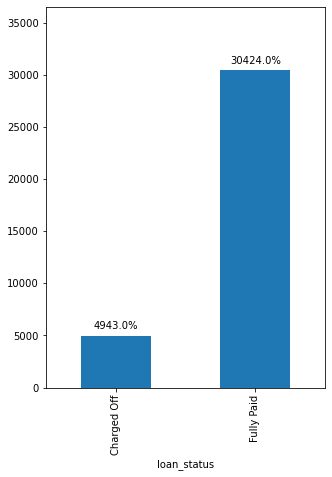

```python
plt.figure(figsize=(5,7))
ax = loan.groupby('loan_status').loan_amnt.count().plot.bar()
showLabels(ax)
plt.show()
```

```python
print("%.2f" % (loan.loc[loan['loan_status'] == 'Charged Off'].loan_status.count() * 100/len(loan)))
```

```
13.98
```

## Approximately *14%* of loans in the dataset are *defaulted*.

### Next, We are looking into loan recovered now.

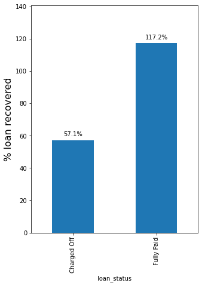

```python
plt.figure(figsize=(5,7))
ax = (loan.groupby('loan_status').total_pymnt.sum() * 100 / loan.groupby('loan_status').loan_amnt.sum()).plot.bar()
ax.set_ylabel('% loan recovered', fontsize=16)
plt.margins(0.2, 0.2)
showLabels(ax)
```

## As per above, Lending Club only recovers *57%* of the loan amount when loans are *'defaulted'*. On fully paid up loans, the company makes *17%* profit.

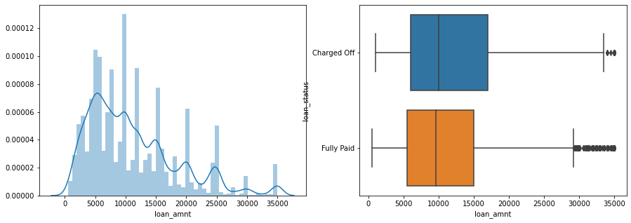

```python
plot_distribution(loan, 'loan_amnt')
```

```python
loan.groupby('loan_status')['loan_amnt'].describe()
```

| loan_status | count | mean | std | min | 25% | 50% | 75% | max |
| --- | --- | --- | --- | --- | --- | --- | --- | --- |
| Charged Off | 4943.0 | 12286.147077 | 8064.255961 | 1000.0 | 6000.0 | 10000.0 | 17000.0 | 35000.0 |
| Fully Paid | 30424.0 | 10945.731166 | 7181.867451 | 500.0 | 5500.0 | 9600.0 | 15000.0 | 35000.0 |

# Observation:

## 1. Overall, the applied loan amount distribution is slightly right-skewed with mean greater than the median. Most of the loans granted are below 15000 (75 percentile value)

## 2. Funding amounts see a spike around each 5000 boundary. We will use 5000 as bucket size for later analysis.

## 3. Charged off loans are shifted towards higher average loan amount request.

```python
#Create Derived categorical variable
loan['loan_amnt_bin'] = pd.cut(loan['loan_amnt'],
                                      [x for x in range(0, 36000, 5000)], labels=[str(x)+'-'+str(x+5)+'k' for x in range (0, 35, 5)])
```

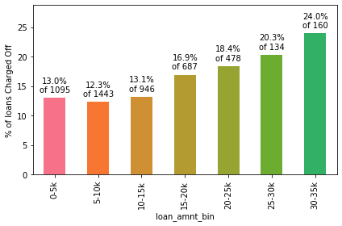

```python
plotLoanStatus(loan, 'loan_amnt_bin')
```

### 1. The % of charged off loans increases substancially as we go up the loan amount buckets. Most loans are below 20000 amount.

### 2. The higher loans, though lesser in number, carry a substantially higher risk of default.

```python
def categoricalBarPlots(df, arr):
    rows = int(len(arr)/2)
    for idx, val in enumerate(arr, start=1):
        plt.subplot(rows, 2, idx)
        ax = df.groupby(val).loan_amnt.count().plot.bar(color=sns.color_palette('husl', 16))
        showLabels(ax)

    plt.tight_layout()
```

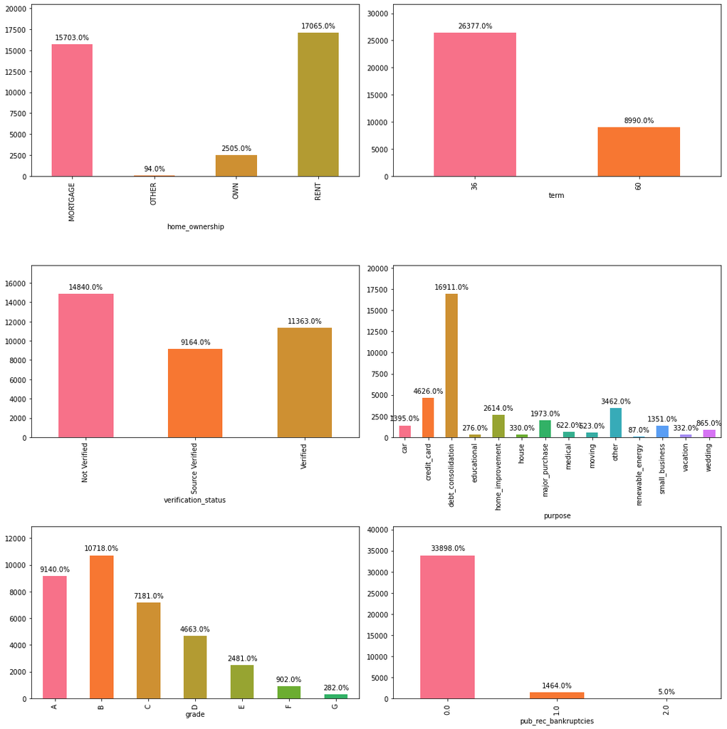

```python
plt.figure(figsize=(15,15))

categoricalBarPlots(loan, ['home_ownership', 'term', 'verification_status', 'purpose', 'grade', 'pub_rec_bankruptcies'])
```

### 1. Most loans are for 36 month term

### 2. Very few loans are extended to people with prior record of bankruptcy

### 3. debt_consolidation is by far the largest 'purpose' for seeking a loan

### 4. Most approved loans are high grade

### 5. We should investigate the frequencies of defaults by term, purpose and prior record of bankruptcy

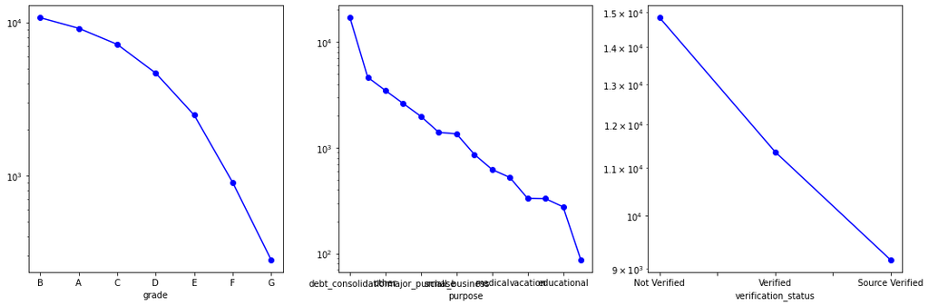

```python
#Let's see if some of these variables follow the famous power law.
plt.figure(figsize=(15,5))
plt.subplot(1, 3, 1)
loan.groupby('grade').loan_amnt.count().sort_values(ascending=False).plot(kind='line', logy=True, marker='o', color='b')
plt.subplot(1, 3, 2)
loan.groupby('purpose').loan_amnt.count().sort_values(ascending=False).plot(kind='line', logy=True, marker='o', color='b')
plt.subplot(1, 3, 3)
loan.groupby('verification_status').loan_amnt.count().sort_values(ascending=False).plot(kind='line', logy=True, marker='o', color='b')
plt.tight_layout()
```

## purpose and verification_status follow the power law

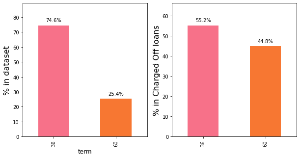

```python
plt.figure(figsize=(10,5))
plot_percentages(loan, 'term')
```

### Around 75% of the total loans are given for duration of 3 years. while just 25% of the loans are those given for 5 years.

### Among Charged Off loans, percentage of term 60 months rises to 45%. The higher term loans have a higher chance of default.

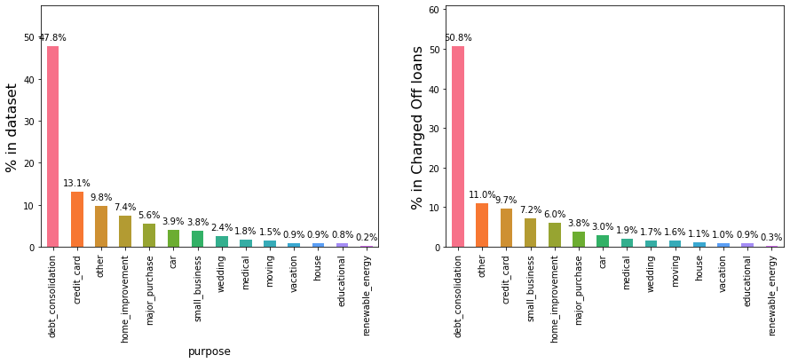

```python
plt.figure(figsize=(15,5))
plot_percentages(loan, 'purpose')
```

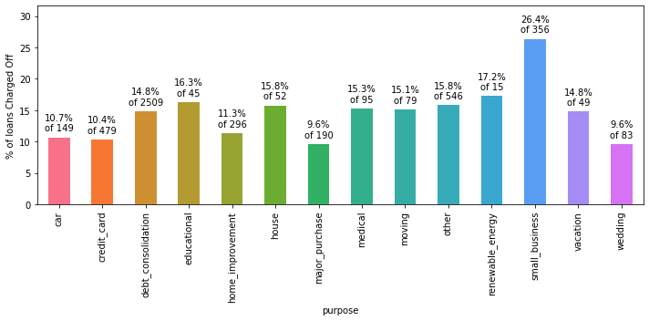

```python
plt.figure(figsize=(10, 5))
plotLoanStatus(loan, 'purpose')
```

## *17%* of the loans for renewable_enrgy are charged Off, but the number is too less to be of significance.

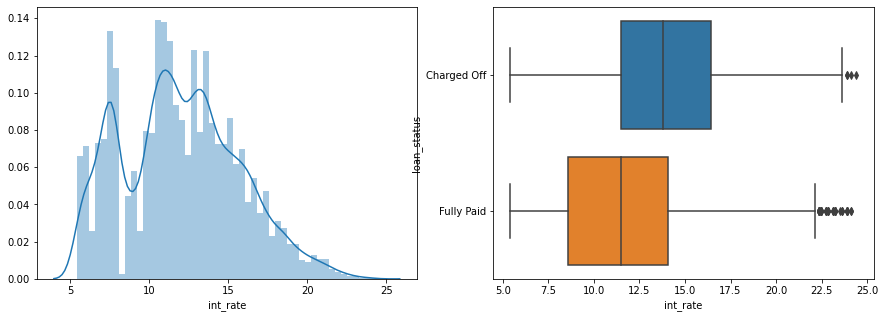

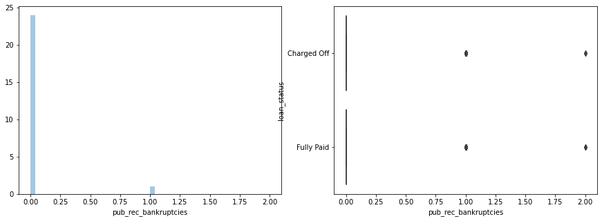

```python
plt.figure(figsize=(7,5))
plt.figure(figsize=(15,5))
plot_distribution(loan, 'int_rate')
plot_distribution(loan, 'pub_rec_bankruptcies')
```

```python
loan.int_rate.describe()
```

```
count    35367.000000
mean        11.983468
std          3.702512
min          5.420000
25%          8.940000
50%         11.830000
75%         14.460000
max         24.400000
Name: int_rate, dtype: float64
```

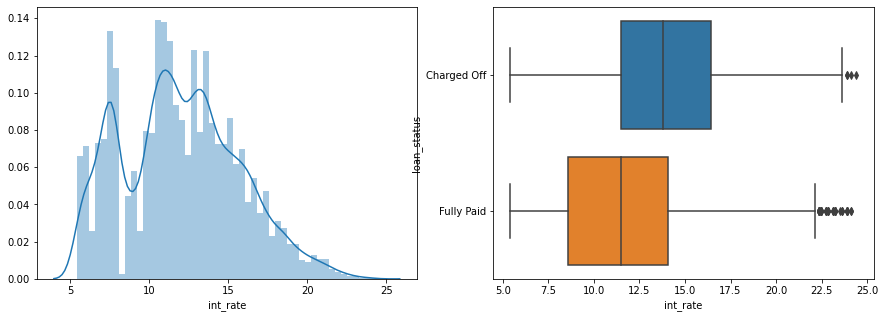

```python
plt.figure(figsize=(15,5))
plot_distribution(loan, 'int_rate')
```

```python
loan.groupby('loan_status')['int_rate'].describe()
```

| loan_status | count | mean | std | min | 25% | 50% | 75% | max |
| --- | --- | --- | --- | --- | --- | --- | --- | --- |
| Charged Off | 4943.0 | 13.929828 | 3.647619 | 5.42 | 11.49 | 13.79 | 16.45 | 24.40 |
| Fully Paid | 30424.0 | 11.667243 | 3.613734 | 5.42 | 8.59 | 11.49 | 14.09 | 24.11 |

## The intrest rate for Charged Off loans appear to be higher than for Fully paid. This is naturally expected.

## As, the risk increases the rate of interest imposed on the loan also increases. Let's analyze this more -

```python
loan['interest_rate_buckets'] = round(loan['int_rate'])
```

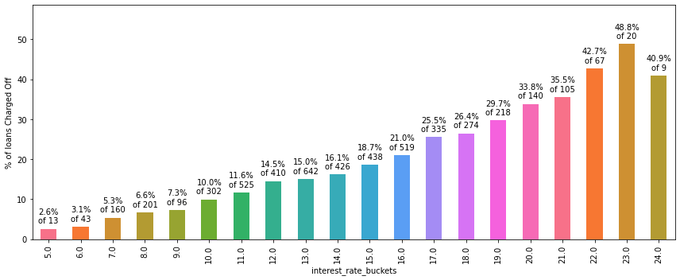

```python
plt.figure(figsize=(12,5))
plotLoanStatus(loan, 'interest_rate_buckets')
```

```python
loan.installment.describe()
```

```
count    35367.000000
mean       324.043982
std        207.149088
min         16.080000
25%        167.840000
50%        280.620000
75%        426.640000
max       1305.190000
Name: installment, dtype: float64
```

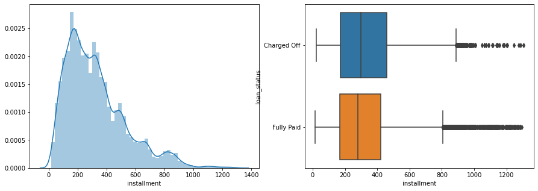

```python
plt.figure(figsize=(15,5))
plot_distribution(loan, 'installment')
```

```python
loan.groupby('loan_status')['installment'].describe()
```

| loan_status | count | mean | std | min | 25% | 50% | 75% | max |
| --- | --- | --- | --- | --- | --- | --- | --- | --- |
| Charged Off | 4943.0 | 338.848452 | 214.527655 | 22.79 | 172.4350 | 298.33 | 458.3150 | 1305.19 |
| Fully Paid | 30424.0 | 321.638693 | 205.828423 | 16.08 | 167.2975 | 278.24 | 422.3075 | 1295.21 |

### *Installment amount* varies largely between 170.08 to 420 with median of 280

### Loans *Charged Off* have high installment on average

```python
loan.grade.value_counts()
```

```
B    10718
A     9140
C     7181
D     4663
E     2481
F      902
G      282
Name: grade, dtype: int64
```

```python
loan.sub_grade.value_counts(normalize=True).head()
```

```
A4    0.075268
B3    0.073204
A5    0.070320
B5    0.069104
B4    0.063534
Name: sub_grade, dtype: float64
```

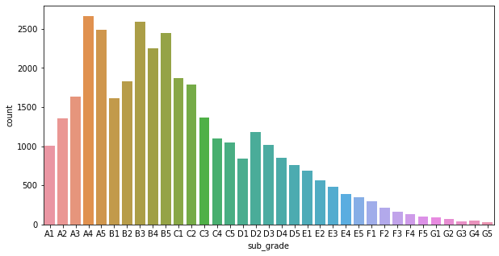

```python
plt.figure(figsize=(10,5))
sns.countplot(loan['sub_grade'], order=sorted(loan.sub_grade.unique()))
plt.show()
```

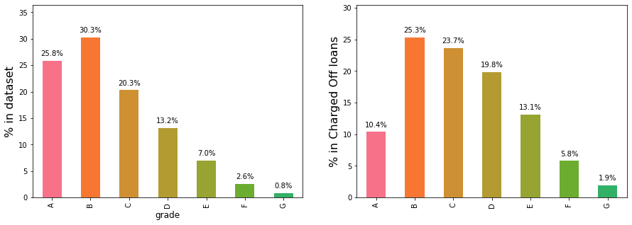

```python
plt.figure(figsize=(15,5))
plot_percentages(loan, 'grade', True)
```

#### We should plot grade by percentage Charged Off by category

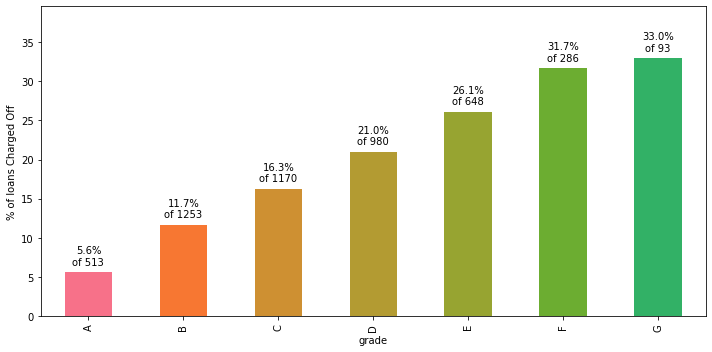

```python
plt.figure(figsize=(10,5))
plotLoanStatus(loan, 'grade')
```

### Nearly 30% of all loans in Grades F and G see a default.

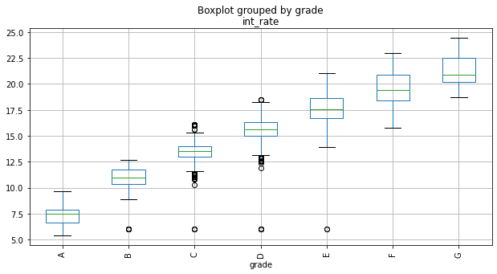

```python
fig, ax = plt.subplots(figsize=(10,5))
loan.boxplot(column=['int_rate'],by='grade', ax=ax, rot=90)
```

### Here, we see that Lending Club is, correctly, charging higher interest rates for lower grade loans.

```python
top10_emp_title = loan.emp_title.value_counts(normalize=False).head(10)
top10_emp_title
```

```
US Army              128
Bank of America      106
IBM                   65
AT&T                  57
Kaiser Permanente     55
Wells Fargo           52
UPS                   51
USAF                  51
US Air Force          50
Walmart               44
Name: emp_title, dtype: int64
```

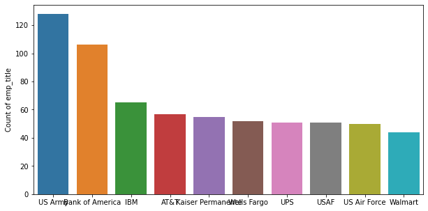

```python
plt.figure(figsize=(10,5))
a=sns.barplot(x=top10_emp_title.index, y=top10_emp_title.values)
a.set_ylabel('Count of emp_title')
plt.show()
```

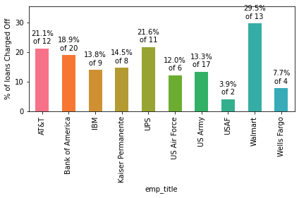

```python
plotLoanStatus(loan[loan['emp_title'].isin(top10_emp_title.index.values)], 'emp_title')
```

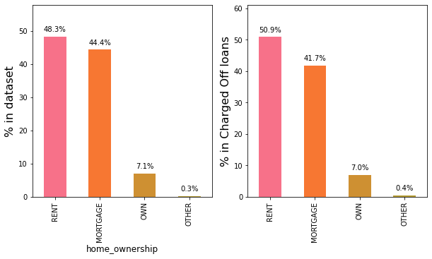

```python
plt.figure(figsize=(10,5))
plot_percentages(loan, 'home_ownership')
```

## There is no impact of *home_ownership* to propensity to default on loan.

```python
loan.annual_inc.describe(percentiles=[0.1, 0.25, 0.5, 0.75, 0.9])
```

```
count    3.536700e+04
mean     6.909599e+04
std      6.396705e+04
min      4.000000e+03
10%      3.000000e+04
25%      4.150000e+04
50%      6.000000e+04
75%      8.250000e+04
90%      1.150000e+05
max      6.000000e+06
Name: annual_inc, dtype: float64
```

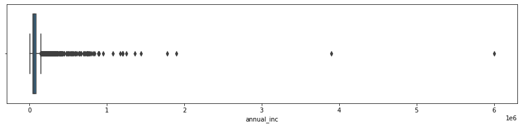

```python
plt.figure(figsize=(15, 3))
sns.boxplot(x=loan['annual_inc'], data=loan)
```

### Let's get rid of outliers to analyze annual income.

### Keep only the ones that are within +3 to -3 standard deviations in the column 'Data'.

```python
df = loan[np.abs(loan.annual_inc-loan.annual_inc.mean()) <= (3*loan.annual_inc.std())]
```

```python
df.annual_inc.describe()
```

```
count     35122.000000
mean      66255.515193
std       35749.840874
min        4000.000000
25%       41004.000000
50%       59449.000000
75%       81969.000000
max      260000.000000
Name: annual_inc, dtype: float64
```

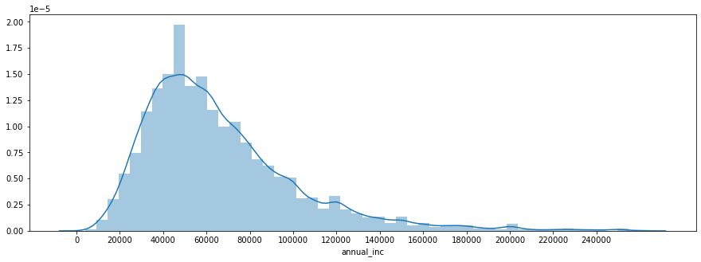

```python
plt.figure(figsize=(15, 5))
sns.distplot(df['annual_inc'], hist_kws={'log':False})
plt.xticks(np.arange(0, 260000, 20000))
plt.show()
```

```python
#Create Derived categorical variable
loan['income_bin'] = loan['annual_inc']/20000
loan['income_bin'] = loan['income_bin'].astype(int)
```

[output not shown]

[figure not shown]

```python
plt.figure(figsize=(10,5))
ax = plotLoanStatus(loan.loc[loan['income_bin']<21], 'income_bin')
ax.set_xticklabels([(str(int(x.get_text())*10)+'-'+str(int(x.get_text())*10+10)+'k') for x in ax.get_xticklabels()])
```

## Loan defaults are higher for lower income, and progressively reduce as incomes go up.

```python
loan.verification_status.value_counts()
```

```
Not Verified       14840
Verified           11363
Source Verified     9164
Name: verification_status, dtype: int64
```

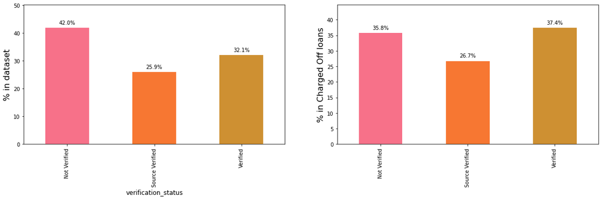

```python
plt.figure(figsize=(20,5))
plot_percentages(loan, 'verification_status', True)
```

### Overall, it appears that there are more *'Non Verified'* loans than the *'Source Verified'* and *'Verified'* loans.

### LC should take steps to verify these loans income so as to reduce the Charge Off percentage.

### *Verified* loans show more *'Charged Off'* percentage as compared to Not verified loans

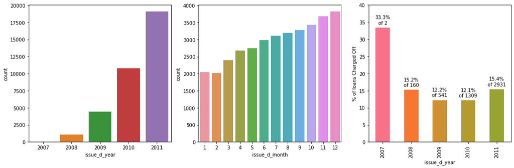

```python
plt.figure(figsize=(15,5))
plt.subplot(1, 3, 1)
sns.countplot(loan['issue_d_year'], order=sorted(loan.issue_d_year.unique()))

plt.subplot(1, 3, 2)
sns.countplot(loan['issue_d_month'], order=sorted(loan.issue_d_month.unique()))

#Fraction of loans charged off and fully Paid
plt.subplot(1, 3, 3)
plotLoanStatus(loan, 'issue_d_year')

plt.show()
```

### Over the years, LC as an organisation has been giving more loans.

### From Aug,2007 to 2011 the loans issued have risen significantly.

### This doesn't have any impact on default

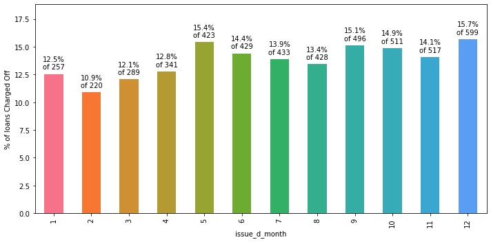

```python
plt.figure(figsize=(10, 5))
plotLoanStatus(loan, 'issue_d_month')
```

```python
loan.title.value_counts().head(10)
```

```
Debt Consolidation           1975
Debt Consolidation Loan      1541
Personal Loan                 589
Consolidation                 462
debt consolidation            440
Credit Card Consolidation     325
Home Improvement              324
Debt consolidation            303
Personal                      281
Credit Card Loan              280
Name: title, dtype: int64
```

```python
loan.addr_state.value_counts(normalize=True).head(10)
```

```
CA    0.180847
NY    0.095739
FL    0.071677
TX    0.069358
NJ    0.047134
IL    0.039048
PA    0.038822
VA    0.035626
GA    0.035429
MA    0.033393
Name: addr_state, dtype: float64
```

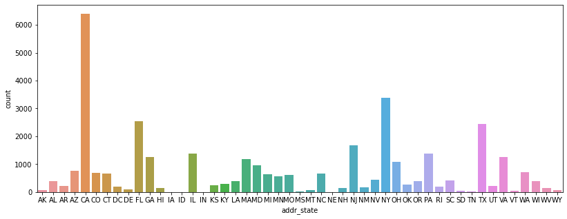

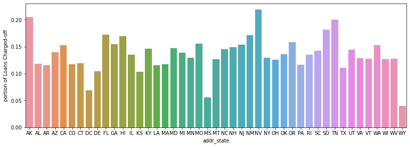

```python
plt.figure(figsize=(30,5))
plt.subplot(1, 2, 1)
sns.countplot(loan['addr_state'], order=sorted(loan.addr_state.unique()))

#Fraction of loans charged off and fully Paid
charge_off_count = loan.groupby('addr_state')['loan_status'].value_counts(normalize=True).loc[:,'Charged Off']
Fully_paid_count = loan.groupby('addr_state')['loan_status'].value_counts(normalize=True).loc[:,'Fully Paid']

plt.figure(figsize=(30,10))
plt.subplot(2, 2, 1)
a=sns.barplot(x=charge_off_count.index, y=charge_off_count.values)
a.set_ylabel('portion of Loans Charged-off')
#plt.subplot(1, 2, 2)
#b=sns.barplot(x=Fully_paid_count.index, y=Fully_paid_count.values)
#b.set_ylabel('portion of Loans Fully Paid')
plt.show()
```

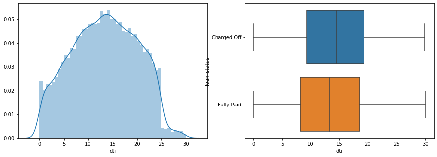

```python
plt.figure(figsize=(10,5))

plot_distribution(loan, 'dti')
```

```python
# Create derived variable
loan['dti_bin'] = pd.cut(loan['dti'], [0,5,10,15,20,25,30], labels=['0-5','5-10','10-15','15-20','20-25','25-30'])
```

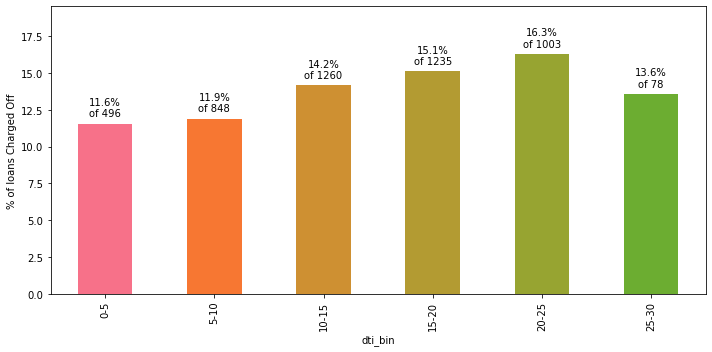

```python
plt.figure(figsize=(10,5))
plotLoanStatus(loan, 'dti_bin')
```